# Data Partitioning and Feature Engineering

Author

Affiliation

Nakul R. Padalkar

Boston University

Published

September 29, 2023

Modified

November 25, 2025

# 1 Importing Data and Packages

The `dplyr` package is used for data manipulation and the `ggplot2` package is used for data visualization. These are frequently used packages in machine learning and have a rich code library available on their website.

```r
# Helper packages
library(dplyr)     # for data manipulation
library(ggplot2)   # for awesome graphics
library(gt)
```

## 1.1 Modeling Process packages

```r
library(rsample)  # for resampling procedures
library(caret)    # for resampling and model training
library(h2o)      # for resampling and model training
```

### 1.1.1 `h20` library

H2O is a fully open-source, distributed in-memory machine-learning platform with linear scalability. H2O supports the most widely used statistical & machine learning algorithms including gradient-boosted machines, generalized linear models, deep learning and more. H2O also has an industry-leading AutoML functionality that automatically runs through all the algorithms and their hyperparameters to produce a leaderboard of the best models. The H2O platform is used by over 18,000 organizations globally and is extremely popular in both the R & Python communities.

```r
# h20 set up

h2o.no_progress() # turn off h20
h2o.init()        # launch h20
```

[output not shown]

## 1.2 Loading and Importing Data

We first need to load the dataset from csv. In real world scenario, this will be a database connection.

```r
# Read your dataset
ames <-read.csv("../data/AmesHousing2.csv")
# ames <- AmesHousing::make_ames()
```

we need to convert the original dataset into an H20 object (to run the models)

```r
ames.h2o0 <-as.h2o(ames)

head(ames$SalePrice)  # response variable
```

```
[1] 171000 139000 159000 136000 230000 190000
```

```r
target <- 'SalePrice'
predictors <- setdiff(colnames(ames), target)
```

Let’s see what the data looks like by looking at the first few rows of the dataset.

```r
library(kableExtra)
kable(head(ames), "html") %>% kable_styling("striped") %>% scroll_box(width = "100%")
```

| Order | Lot.Frontage | Lot.Area | Lot.Shape | Utilities | Lot.Config | Land.Slope | Neighborhood | Bldg.Type | House.Style | Overall.Qual | Overall.Cond | Year.Built | Year.Remod.Add | Foundation | Bsmt.Unf.SF | Total.Bsmt.SF | BaseLivArea | Central.Air | X1st.Flr.SF | X2nd.Flr.SF | Gr.Liv.Area | Full.Bath | Half.Bath | Bathrooms | Bedroom.AbvGr | Kitchen.AbvGr | Kitchen.Qual | TotRms.AbvGrd | Fireplaces | … |
| --- | --- | --- | --- | --- | --- | --- | --- | --- | --- | --- | --- | --- | --- | --- | --- | --- | --- | --- | --- | --- | --- | --- | --- | --- | --- | --- | --- | --- | --- | --- |
| 117 | 80 | 9600 | Reg | AllPub | Inside | Gtl | NWAmes | 1Fam | 2Story | 6 | 6 | 1971 | 1971 | CBlock | 386 | 715 | 329 | Y | 930 | 715 | 1645 | 1 | 2 | 2 | 4 | 1 | TA | 7 | 0 | … |
| 325 | 94 | 9400 | Reg | AllPub | Corner | Gtl | Mitchel | Duplex | 2Story | 6 | 5 | 1971 | 1971 | CBlock | 912 | 912 | 0 | Y | 912 | 912 | 1824 | 2 | 2 | 3 | 4 | 2 | TA | 8 | 0 | … |
| 337 | 70 | 7700 | Reg | AllPub | Inside | Gtl | Mitchel | Duplex | 2Story | 5 | 2 | 1985 | 1986 | PConc | 1216 | 1216 | 0 | Y | 1216 | 1216 | 2432 | 4 | 2 | 5 | 4 | 2 | TA | 10 | 0 | … |
| 393 | 60 | 9000 | Reg | AllPub | FR2 | Gtl | NAmes | Duplex | 2Story | 5 | 5 | 1974 | 1974 | CBlock | 896 | 896 | 0 | Y | 896 | 896 | 1792 | 2 | 2 | 3 | 4 | 2 | TA | 8 | 0 | … |
| 590 | NA | 13774 | IR1 | AllPub | Inside | Gtl | NWAmes | 1Fam | 2Story | 7 | 7 | 1977 | 1992 | PConc | 476 | 908 | 432 | Y | 1316 | 972 | 2288 | 1 | 2 | 2 | 4 | 1 | Gd | 8 | 2 | … |
| 667 | 81 | 9671 | Reg | AllPub | Corner | Gtl | NAmes | Duplex | 2Story | 6 | 5 | 1969 | 1969 | CBlock | 1248 | 1248 | 0 | Y | 1248 | 1296 | 2544 | 2 | 2 | 3 | 6 | 2 | TA | 12 | 0 | … |

```r
# head(ames)
```

Now let the summary of the dataset

```r
library(gtsummary)
summary(ames)
```

```
     Order         Lot.Frontage       Lot.Area       Lot.Shape
 Min.   :   1.0   Min.   : 21.00   Min.   :  1300   Length:2930
 1st Qu.: 733.2   1st Qu.: 58.00   1st Qu.:  7440   Class :character
 Median :1465.5   Median : 68.00   Median :  9436   Mode  :character
 Mean   :1465.5   Mean   : 69.22   Mean   : 10148
 3rd Qu.:2197.8   3rd Qu.: 80.00   3rd Qu.: 11555
 Max.   :2930.0   Max.   :313.00   Max.   :215245
                  NA's   :490
  Utilities          Lot.Config         Land.Slope        Neighborhood
 Length:2930        Length:2930        Length:2930        Length:2930
 Class :character   Class :character   Class :character   Class :character
 Mode  :character   Mode  :character   Mode  :character   Mode  :character




  Bldg.Type         House.Style         Overall.Qual     Overall.Cond
 Length:2930        Length:2930        Min.   : 1.000   Min.   :1.000
 Class :character   Class :character   1st Qu.: 5.000   1st Qu.:5.000
 Mode  :character   Mode  :character   Median : 6.000   Median :5.000
                                       Mean   : 6.095   Mean   :5.563
                                       3rd Qu.: 7.000   3rd Qu.:6.000
                                       Max.   :10.000   Max.   :9.000

   Year.Built   Year.Remod.Add  Foundation         Bsmt.Unf.SF
 Min.   :1872   Min.   :1950   Length:2930        Min.   :   0.0
 1st Qu.:1954   1st Qu.:1965   Class :character   1st Qu.: 219.0
 Median :1973   Median :1993   Mode  :character   Median : 466.0
 Mean   :1971   Mean   :1984                      Mean   : 559.3
 3rd Qu.:2001   3rd Qu.:2004                      3rd Qu.: 802.0
 Max.   :2010   Max.   :2010                      Max.   :2336.0
                                                  NA's   :1
 Total.Bsmt.SF   BaseLivArea     Central.Air         X1st.Flr.SF
 Min.   :   0   Min.   :   0.0   Length:2930        Min.   : 334.0
 1st Qu.: 793   1st Qu.:   0.0   Class :character   1st Qu.: 876.2
 Median : 990   Median : 459.5   Mode  :character   Median :1084.0
 Mean   :1052   Mean   : 492.2                      Mean   :1159.6
 3rd Qu.:1302   3rd Qu.: 808.0                      3rd Qu.:1384.0
 Max.   :6110   Max.   :5644.0                      Max.   :5095.0
 NA's   :1
```

[output cut: 32 more lines]

```
  Screen.Porch    Mo.Sold          Yr.Sold     Sale.Condition
 Min.   :  0   Min.   : 1.000   Min.   :2006   Length:2930
 1st Qu.:  0   1st Qu.: 4.000   1st Qu.:2007   Class :character
 Median :  0   Median : 6.000   Median :2008   Mode  :character
 Mean   : 16   Mean   : 6.216   Mean   :2008
 3rd Qu.:  0   3rd Qu.: 8.000   3rd Qu.:2009
 Max.   :576   Max.   :12.000   Max.   :2010

   SalePrice
 Min.   : 12789
 1st Qu.:129500
 Median :160000
 Mean   :180796
 3rd Qu.:213500
 Max.   :755000
```

Let’s see a better table for the summary

```r
 ames %>%
 gtsummary::tbl_summary(
  ) %>%
  gtsummary::bold_labels() %>%
  gtsummary::as_kable_extra(
    format = "html",
    longtable = TRUE,
    linesep = ""
    ) %>%
  kableExtra::kable_styling(
      position = "left",
      latex_options = c("striped", "repeat_header"),
      stripe_color = "gray!15"
    )
```

| Characteristic | N = 2,930 |
| --- | --- |
| Order | 1,466 (733, 2,198) |
| Lot.Frontage | 68 (58, 80) |
| Unknown | 490 |
| Lot.Area | 9,437 (7,440, 11,556) |
| Lot.Shape |  |
| IR1 | 979 (33%) |
| IR2 | 76 (2.6%) |
| IR3 | 16 (0.5%) |
| Reg | 1,859 (63%) |
| Utilities |  |
| AllPub | 2,927 (100%) |
| NoSeWa | 1 (<0.1%) |
| NoSewr | 2 (<0.1%) |
| Lot.Config |  |
| Corner | 511 (17%) |
| CulDSac | 180 (6.1%) |
| FR2 | 85 (2.9%) |
| FR3 | 14 (0.5%) |
| Inside | 2,140 (73%) |
| Land.Slope |  |
| Gtl | 2,789 (95%) |
| Mod | 125 (4.3%) |
| Sev | 16 (0.5%) |
| Neighborhood |  |
| Blmngtn | 28 (1.0%) |
| Blueste | 10 (0.3%) |
| BrDale | 30 (1.0%) |
| BrkSide | 108 (3.7%) |
| ClearCr | 44 (1.5%) |
| CollgCr | 267 (9.1%) |

[output cut: 136 more lines]

<sup>1</sup> Median (Q1, Q3); n (%)

## 1.3 Variable separation

The dataset contains both numeric and categorical variables. We need to separate them for further analysis. This is especially important for feature engineering.

```r
num_vars<-colnames(ames[sapply(ames, is.numeric) == TRUE])
cat_vars<-colnames(ames[sapply(ames, is.character) == TRUE])
```

## 1.4 Side note on text and variable outputs

There are two ways we can use the variables from the r code in the text. The first one is by using `stmt` output using `print` and the other is using `r` output.

### 1.4.1 Statement output

```r
stmt <- paste("There are", length(num_vars), "numerical features and", length(cat_vars), "categorical features" )
print(stmt, na.print = NULL)
```

```
[1] "There are 29 numerical features and 12 categorical features"
```

### 1.4.2 `r` output

There are 29 *numerical features* and 12 *categorical features* in this dataset.

# 2 Resampling Methods

## 2.1 Test Set Approach

There are multiple ways to split your data in R (four ways shown below)Simple Random Sampling is one of them.

### 2.1.1 Using base R

```r
set.seed(123)  # for reproducibility
index_1 <- sample(1:nrow(ames), round(nrow(ames) * 0.8))
train_1 <- ames[index_1, ]
test_1  <- ames[-index_1, ]

# kable(head(train), "html") %>% kable_styling("striped") %>% scroll_box(width = "100%")
print(dim(train_1))
```

```
[1] 2344   41
```

```r
print(dim(test_1))
```

```
[1] 586  41
```

### 2.1.2 Using `caret` package

```r
set.seed(123)  # for reproducibility
index_2 <- createDataPartition(ames$SalePrice, p = 0.7,
                               list = FALSE)
train_2 <- ames[index_2, ]
test_2  <- ames[-index_2, ]
```

### 2.1.3 Using `rsample` package

```r
set.seed(123)  # for reproducibility
split_1  <- initial_split(ames, prop = 0.7)
train_3  <- training(split_1)
test_3   <- testing(split_1)
```

### 2.1.4 Using h2o package

```r
split_2 <- h2o.splitFrame(ames.h2o0, ratios = 0.7,
                          seed = 123)
train_4 <- split_2[[1]]
test_4  <- split_2[[2]]
```

## 2.2 The Validation Set Approach

Draw a sample of size `nrow(ames)` from the numbers 1 to 3 (with replacement). You want approximately 70% of the sample to be 1 and the remaining 30% to be equally split between 2 and 3.

```r
set.seed(123)
part <-sample(1:3, size=nrow(ames), prob=c(0.7, 0.15, 0.15), replace=TRUE)
```

We can also create training, validation, and testing sets from the original data frame directly.

```r
train_5 <-ames[part == 1, ] #subset ames to training indices only
valid_5 <-ames[part == 2, ]
test_5 <-ames[part == 3, ]
```

## 2.3 Stratified Random Sampling

The easiest way to perform stratified sampling on a response variable is to use the `rsample` package, where you specify the response variable to strata. The following illustrates that in our original employee attrition data we have an imbalanced response (No: 84%, Yes: 16%). By enforcing stratified sampling, both our training and testing sets have approximately equal response distributions.

Let’s import Job Attrition data from the `rsample` package.

```r
# Job attrition data
library(rsample)
library(modeldata)
churn <- attrition %>%
  mutate_if(is.ordered, .funs = factor, ordered = FALSE)
churn.h2o <- as.h2o(churn)
```

### 2.3.1 Original response distribution

```r
t(table(churn$Attrition)) %>% prop.table() %>% round(4) %>% kbl(format = "html",table.attr = "style='width:30%;'") %>% kable_styling(bootstrap_options = c("striped", "hover", "condensed", "responsive"),full_width = F, position = "center")
```

| No | Yes |
| --- | --- |
| 0.8388 | 0.1612 |

### 2.3.2 Stratified sampling with the `rsample` package

```r
set.seed(123)
split_strat  <- initial_split(churn, prop = 0.7,
                              strata = "Attrition")
train_strat  <- training(split_strat)
test_strat   <- testing(split_strat)

split <- initial_split(ames, prop = 0.7,
                       strata = "SalePrice")
ames_train  <- training(split)
ames_test   <- testing(split)
```

### 2.3.3 Consistent response ratio between train & test

```r
library(dplyr)
library(kableExtra)

train_strat$Attrition %>%
  table() %>%
  t() %>%
  prop.table() %>%
  round(4) %>%
  knitr::kable(format = "html", table.attr = "style='width:30%;'") %>%
  kableExtra::kable_styling(
    bootstrap_options = c("striped", "hover", "condensed", "responsive"),
    full_width = F,
    position = "center"
  )
```

| No | Yes |
| --- | --- |
| 0.8395 | 0.1605 |

Now Test Dataframe

```r
t(table(test_strat$Attrition)) %>% prop.table() %>% round(4) %>% knitr::kable(format = "html", table.attr = "style='width:30%;'") %>% kable_styling(bootstrap_options = c("striped", "hover", "condensed", "responsive"),full_width = F, position = "center")
```

| No | Yes |
| --- | --- |
| 0.8371 | 0.1629 |

# 3 Feature Engineering

Feature engineering is the process of transforming raw data into informative features that better represent the underlying patterns in the data, aiming to improve the performance of machine learning models. By leveraging domain knowledge, statistical techniques, and creative transformations, practitioners craft new features, select relevant ones, or refine existing variables to make algorithms more effective and efficient. This process often plays a crucial role in enhancing model accuracy, generalization, and interpretability (Heaton 2016).

## 3.1 Loading packages

```r
library(dplyr)    # for data manipulation
library(ggplot2)  # for awesome graphics
library(visdat)   # for additional visualizations

# Feature engineering packages
library(caret)    # for various ML tasks
library(recipes)  # for feature engineering tasks
```

## 3.2 Transformation

Let’s create a histogram of the SalePrice variable to understand the distribution of the variable.

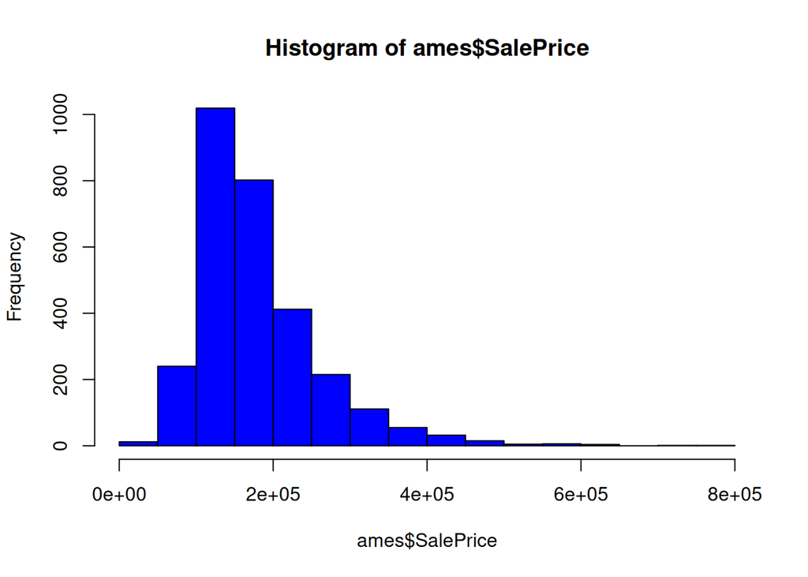

```r
hist(ames$SalePrice, col ='blue')
```

It seems like the variable is skewed. We can apply a transformation to normalize the data to stick to the normality assumption. Let’s also calculate the moments of the variable to understand how much data is skewed. Also, this looks ugly; can we make it look better?

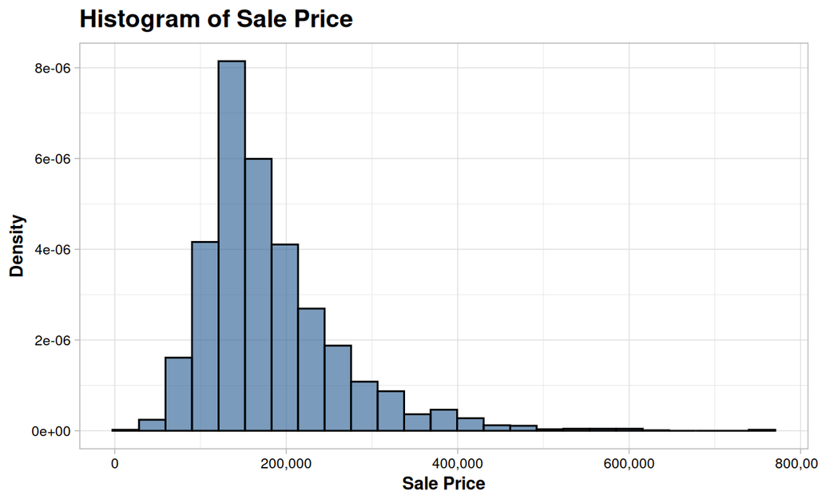

```r
library(ggplot2)
# color =  color of the histogram border
library(ggplot2)
library(scales)

ggplot(ames, aes(x = SalePrice)) +
  geom_histogram(aes(y = after_stat(density)), fill = "#336699", color = "black", alpha = 0.65, bins = 25) +
  labs(x = "Sale Price", y = "Density", title="Histogram of Sale Price") +
  scale_x_continuous(labels = label_comma(accuracy = 1)) +
  # scale_y_continuous(labels = label_comma(accuracy = 1)) +
  theme_light() +
  theme(
    plot.title = element_text(hjust = 0, face = "bold", size = 14),  # Left-align (hjust = 0) and bold the title
    axis.title.x = element_text(size = 10, color = "black", face="bold"),
    axis.title.y = element_text(size = 10, color = "black", face="bold"),
    axis.text.x = element_text(size = 8, color = "black"),
    axis.text.y = element_text(size = 8, color = "black")
  )
```

```r
# install.packages("moments")
library(moments)
saleprice_skew <- skewness(ames$SalePrice)
```

Skewness is $1.7426074 (>1)$, which indicates that data is positively or right skewed.

## 3.3 Variable Transformation

### 3.3.1 Log Transformation

Transform the variable to a log transformation (natural log of variable)

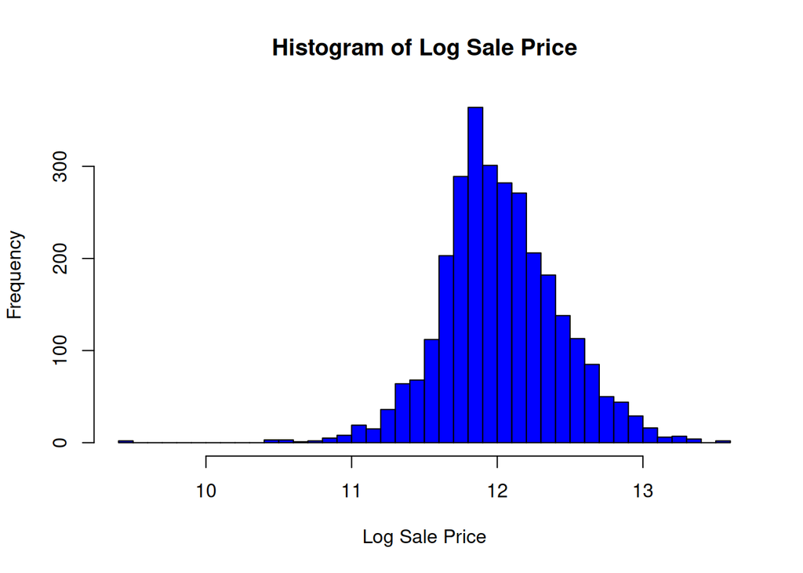

```r
ln_sales <-log(ames$SalePrice)

hist(ln_sales, col='blue', breaks = 40, main = "Histogram of Log Sale Price", xlab = "Log Sale Price", ylab = "Frequency")
```

```r
log_sales = skewness(ln_sales)
```

The distribution appears to conform to a normal distribution. The skewness value is -0.0147859. The transformation has caused the distribution to become slightly negatively skewed. However, the variable’s distribution (output) is now closer to 0.

### 3.3.2 Square Root Transformation

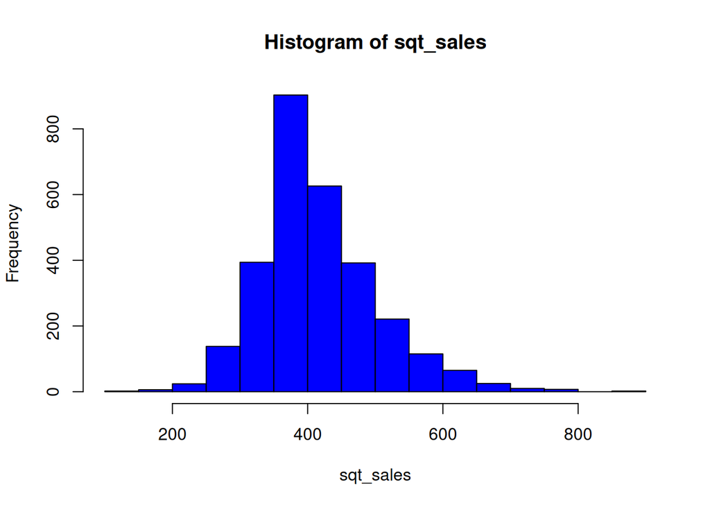

```r
sqt_sales <- sqrt(ames$SalePrice)
hist(sqt_sales, col='blue')
```

```r
sq_skewness<- skewness(sqt_sales)
```

The distribution is not as normal as that of log transformation. The skewness value is 0.8843168, which means data is moderately positively skewed and performs worse than log transformation.

### 3.3.3 Cube-Root Transformation

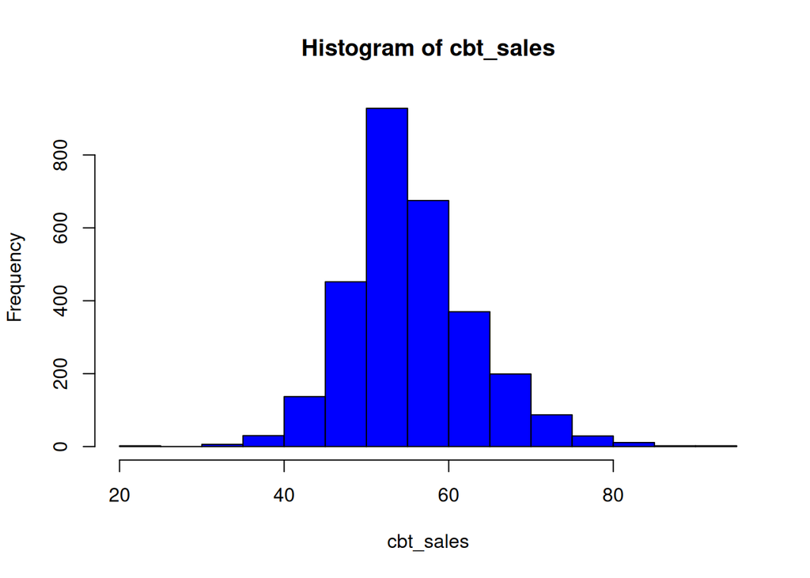

```r
cbt_sales <- (ames$SalePrice)^(1/3)
hist(cbt_sales, col='blue')
```

```r
cbt_skewnes <- skewness(cbt_sales)
```

The data distribution is worse than log transformation but better than square root. The skewness value is 0.6069153, meaning data is positively skewed and performs better than square root (you may use log transformation).

### 3.3.4 Box-Cox Transformation

```r
# | message: false
# load package
library(sjPlot)
library(sjmisc)
library(sjlabelled)
m.ols <- lm(SalePrice ~ Gr.Liv.Area, data=ames)
ols_summ <- summary(m.ols)

tab_model(m.ols)
```

|  | Sale Price |  |  |
| --- | --- | --- | --- |
| Predictors | Estimates | CI | p |
| (Intercept) | 13289.63 | 6878.48 – 19700.78 | **<0.001** |
| Gr Liv Area | 111.69 | 107.64 – 115.75 | **<0.001** |
| Observations | 2930 |  |  |
| R<sup>2</sup> / R<sup>2</sup> adjusted | 0.500 / 0.499 |  |  |

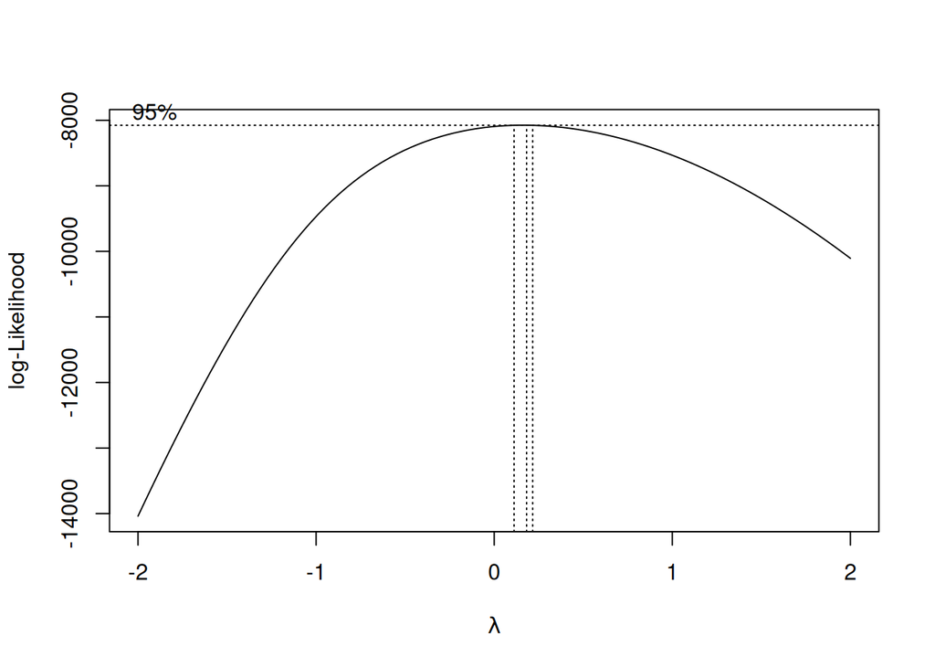

```r
library(MASS)
bc <- boxcox(m.ols)
```

```r
str(bc)
```

```
List of 2
 $ x: num [1:100] -2 -1.96 -1.92 -1.88 -1.84 ...
 $ y: num [1:100] -14038 -13806 -13577 -13351 -13127 ...
```

```r
(bc.power <- bc$x[which.max(bc$y)])
```

```
[1] 0.1818182
```

$$y_{transform}= (y^{\lambda}-1)/\lambda$$
We need to transform the response variable accordingly and re-compute the linear model with this transformed variable. We can write a function corresponding to the formula:

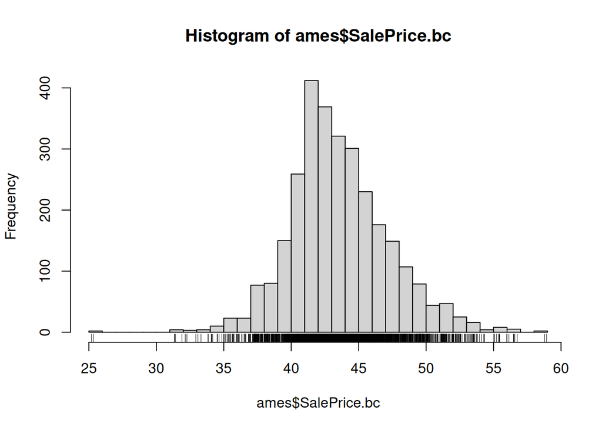

```r
BCTransform <- function(y, lambda=0) {
  if (lambda == 0L) { log(y) }
  else { (y^lambda - 1) / lambda }
}

#Reverse Transformation
BCTransformInverse <- function(yt, lambda=0) {
  if (lambda == 0L) { exp(yt) }
  else { exp(log(1 + lambda * yt)/lambda) }
}

ames$SalePrice.bc <- BCTransform(ames$SalePrice, bc.power)
hist(ames$SalePrice.bc, breaks=30); rug(ames$SalePrice.bc)
```

```r
SPbc_skewness <- skewness(ames$SalePrice.bc)

summary(m.ols.bc <- lm(SalePrice.bc ~ Gr.Liv.Area, data=ames))
```

```
Call:
lm(formula = SalePrice.bc ~ Gr.Liv.Area, data = ames)

Residuals:
     Min       1Q   Median       3Q      Max
-21.5363  -1.3894   0.1928   1.4254   8.5499

Coefficients:
             Estimate Std. Error t value Pr(>|t|)
(Intercept) 3.594e+01  1.497e-01  240.14   <2e-16 ***
Gr.Liv.Area 5.085e-03  9.456e-05   53.78   <2e-16 ***
---
Signif. codes:  0 '***' 0.001 '**' 0.01 '*' 0.05 '.' 0.1 ' ' 1

Residual standard error: 2.587 on 2928 degrees of freedom
Multiple R-squared:  0.4969,    Adjusted R-squared:  0.4967
F-statistic:  2892 on 1 and 2928 DF,  p-value: < 2.2e-16
```

## 3.4 Feature Scaling

Let’s look at one of the continuous variables, `Living Area`. We want to scale the feature. In general, feature scaling refers to the process of standardizing the range of data features. Since the content of raw data values varies widely, in some machine learning algorithms, objective functions will not work properly without normalization.

We can perform `Min-Max` scaling or `Z-score` scaling. Min-Max Scaling transforms the data to a range between 0 and 1. Z-score scaling transforms the data into a mean of 0 and a standard deviation of 1.

The formula for Min-Max scaling is:

$$\begin{align}
x_{scaled} = \frac{x - x_{min}}{x_{max} - x_{min}}
\end{align}$$

The formula for Z-score scaling is:

$$\begin{align}
z = \frac{x - \mu}{\sigma}
\end{align}$$

where $x$ is the original feature vector, $\mu$ is the mean of that feature vector, and $\sigma$ is its standard deviation.

```r
G <-ames$Gr.Liv.Area
A <-ames$Lot.Area
max_A <- max(A)
min_A <- min(A)
max_G <- max(G)
min_G <- min(G)
```

The range of `Gr.Liv.Area` is 334 to 5642. The range of `Lot.Area` is 1300 to 215245.

### 3.4.1 Min-Max Scaling

```r
Gr.Liv.Area_N = (G-min_G)/(max_G-min_G)
Lot.Area_N = (A-min_A)/(max_A-min_A)

minmaxscaler <-cbind.data.frame(ames, Gr.Liv.Area_N, Lot.Area_N)
head(minmaxscaler)
```

```
  Order Lot.Frontage Lot.Area Lot.Shape Utilities Lot.Config Land.Slope
1   117           80     9600       Reg    AllPub     Inside        Gtl
2   325           94     9400       Reg    AllPub     Corner        Gtl
3   337           70     7700       Reg    AllPub     Inside        Gtl
4   393           60     9000       Reg    AllPub        FR2        Gtl
5   590           NA    13774       IR1    AllPub     Inside        Gtl
6   667           81     9671       Reg    AllPub     Corner        Gtl
  Neighborhood Bldg.Type House.Style Overall.Qual Overall.Cond Year.Built
1       NWAmes      1Fam      2Story            6            6       1971
2      Mitchel    Duplex      2Story            6            5       1971
3      Mitchel    Duplex      2Story            5            2       1985
4        NAmes    Duplex      2Story            5            5       1974
5       NWAmes      1Fam      2Story            7            7       1977
6        NAmes    Duplex      2Story            6            5       1969
  Year.Remod.Add Foundation Bsmt.Unf.SF Total.Bsmt.SF BaseLivArea Central.Air
```

[output cut: 41 more lines]

### 3.4.2 Standardize (z scores)

```r
z_Gr.Liv.Area <- (ames$Gr.Liv.Area -mean(ames$Gr.Liv.Area))/sd(ames$Gr.Liv.Area)
z_Lot.Area <-(ames$Lot.Area -mean(ames$Lot.Area))/sd(ames$Lot.Area)

zscore <-cbind.data.frame(ames, z_Gr.Liv.Area, z_Lot.Area)
head(zscore)
```

```
  Order Lot.Frontage Lot.Area Lot.Shape Utilities Lot.Config Land.Slope
1   117           80     9600       Reg    AllPub     Inside        Gtl
2   325           94     9400       Reg    AllPub     Corner        Gtl
3   337           70     7700       Reg    AllPub     Inside        Gtl
4   393           60     9000       Reg    AllPub        FR2        Gtl
5   590           NA    13774       IR1    AllPub     Inside        Gtl
6   667           81     9671       Reg    AllPub     Corner        Gtl
  Neighborhood Bldg.Type House.Style Overall.Qual Overall.Cond Year.Built
1       NWAmes      1Fam      2Story            6            6       1971
2      Mitchel    Duplex      2Story            6            5       1971
3      Mitchel    Duplex      2Story            5            2       1985
4        NAmes    Duplex      2Story            5            5       1974
5       NWAmes      1Fam      2Story            7            7       1977
6        NAmes    Duplex      2Story            6            5       1969
  Year.Remod.Add Foundation Bsmt.Unf.SF Total.Bsmt.SF BaseLivArea Central.Air
```

[output cut: 41 more lines]

## 3.5 Feature Construction

### 3.5.1 Unsupervised Binning

Automatic Binning can be used to determine the number of bins to be created. The bins are created based on the distribution of the data. The bins are created so that the data points in each bin are more similar and the data points in different bins are less similar.

```r
summary(ames$Overall.Qual)
```

```
   Min. 1st Qu.  Median    Mean 3rd Qu.    Max.
  1.000   5.000   6.000   6.095   7.000  10.000
```

```r
count(ames, Overall.Qual)
```

```
   Overall.Qual   n
1             1   4
2             2  13
3             3  40
4             4 226
5             5 825
6             6 732
7             7 602
8             8 350
9             9 107
10           10  31
```

```r
Overall.Qual_Bin <- cut(ames$Overall.Qual, breaks=4)
head(Overall.Qual_Bin)
```

```
[1] (5.5,7.75] (5.5,7.75] (3.25,5.5] (3.25,5.5] (5.5,7.75] (5.5,7.75]
Levels: (0.991,3.25] (3.25,5.5] (5.5,7.75] (7.75,10]
```

### 3.5.2 Manual binning

We need to know the min and max values. For example, say `min=1` and `max=10` then the bins will be `0-5`, `5-6`, `6-7`, `7-10`.

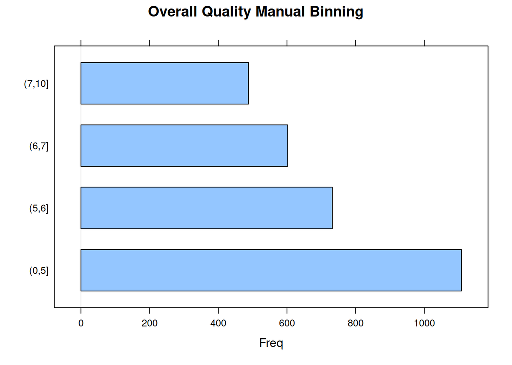

```r
Overall.Qual_MBin <- cut(ames$Overall.Qual, breaks = c(0, 5, 6, 7, 10))
barchart(Overall.Qual_MBin, main = "Overall Quality Manual Binning")
```

Sometimes, features will contain levels that have very few observations. For example, there are 28 unique neighborhoods represented in the Ames housing data, but several of them have fewer observations than the others.

```r
count(train_1, Neighborhood) %>% arrange(n) %>% head() %>% kbl() %>% kable_styling(bootstrap_options = c("striped", "hover", "condensed", "responsive"),full_width = F, position = "center")
```

| Neighborhood | n |
| --- | --- |
| Landmrk | 1 |
| GrnHill | 2 |
| Blueste | 8 |
| Greens | 8 |
| NPkVill | 15 |
| Veenker | 21 |

```r
library(flextable)
arrange(count(train_1, Screen.Porch),n) %>% flextable()
```

| Screen.Porch | n |
| --- | --- |
| 40 | 1 |
| 53 | 1 |
| 60 | 1 |
| 63 | 1 |
| 64 | 1 |
| 80 | 1 |
| 88 | 1 |
| 90 | 1 |
| 94 | 1 |
| 95 | 1 |
| 99 | 1 |
| 104 | 1 |
| 109 | 1 |
| 111 | 1 |
| 113 | 1 |
| 117 | 1 |
| 119 | 1 |
| 121 | 1 |
| 122 | 1 |
| 123 | 1 |
| 126 | 1 |
| 128 | 1 |
| 130 | 1 |
| 135 | 1 |
| 141 | 1 |
| 143 | 1 |
| 145 | 1 |
| 150 | 1 |
| 152 | 1 |
| 154 | 1 |

[output cut: 78 more lines]

### 3.5.3 Standardize and Normalize

```r
# Normalize all numeric columns
recipe(SalePrice ~ ., data = train_1) %>%
    step_YeoJohnson(all_numeric())
```

```
── Recipe ──────────────────────────────────────────────────────────────────────
```

```
── Inputs
```

```
Number of variables by role
```

```
outcome:    1
predictor: 40
```

```
── Operations
```

```
• Yeo-Johnson transformation on: all_numeric()
```

```r
##standardize

# train_1 %>%
#     step_center(all_numeric(), -all_outcomes()) %>%
#     step_scale(all_numeric(), -all_outcomes())
```

### 3.5.4 Lump levels for two features

```r
# lumping <- recipe(SalePrice ~ ., data = train_1) %>%
#   step_other(Neighborhood, threshold = 0.01,
#              other = "other") %>%
#   step_other(Screen.Porch, threshold = 0.1,
#              other = ">0")

lumping <- recipe(SalePrice ~ ., data = train_1) %>%
  step_mutate(Screen.Porch = factor(ifelse(Screen.Porch > 0, ">0", "0"))) %>%
  step_other(Neighborhood, threshold = 0.01, other = "other") %>%
  step_other(Screen.Porch, threshold = 0.1, other = ">0")
```

### 3.5.5 Apply this blueprint

```r
apply_2_training <- prep(lumping, training = train_1) %>%
  bake(train_1)
```

### 3.5.6 New distribution of Neighborhood

```r
count(apply_2_training, Neighborhood) %>% arrange(n) %>% flextable()
```

| Neighborhood | n |
| --- | --- |
| BrDale | 27 |
| MeadowV | 34 |
| ClearCr | 36 |
| StoneBr | 39 |
| SWISU | 41 |
| NoRidge | 54 |
| Timber | 58 |
| IDOTRR | 74 |
| other | 77 |
| Crawfor | 88 |
| BrkSide | 89 |
| Mitchel | 99 |
| NWAmes | 103 |
| SawyerW | 103 |
| Sawyer | 126 |
| NridgHt | 130 |
| Gilbert | 133 |
| Edwards | 141 |
| Somerst | 142 |
| OldTown | 183 |
| CollgCr | 213 |
| NAmes | 354 |

### 3.5.7 New distribution of Screen.Porch

```r
count(apply_2_training, Screen.Porch) %>% arrange(n) %>% flextable()
```

| Screen.Porch | n |
| --- | --- |
| >0 | 207 |
| 0 | 2,137 |

### 3.5.8 Variable Encoding

The categorical variables are very often found in data while conducting data analysis and ML(machine learning). The Data which can be classified into categories or groups, such as colors or job titles is generally called as categorical data. The categorical variables must be encoded into numerical values in order to be used in statistical analysis or ML models.

**Warning: Dummies package is no longer available in R repository**.

#### 3.5.8.1 Using `fastDummies` package

We can create dummy variables for all cat variables in the dataset

```r
library(fastDummies)
ames_train_dummies <- dummy_cols(train_1, select_columns = NULL, remove_first_dummy = TRUE)
ames_test_dummies <- dummy_cols(test_1, select_columns = NULL, remove_first_dummy = TRUE)
```

#### 3.5.8.2 One-hot encoding (`caret`)

```r
# Create dummy variables transformation
dummies <- dummyVars(SalePrice ~ ., data = ames)

# Apply transformation to dataset
ames_dummies <- data.frame(predict(dummies, newdata = ames))
```

#### 3.5.8.3 Label encoding (`caret`)

```r
# Identify columns with class 'factor'
factor_columns <- sapply(ames, is.factor)

# Apply label encoding on those columns
ames[factor_columns] <- lapply(ames[factor_columns], function(x) as.numeric(as.factor(x)))
```

Here, we only had one class variable for multiple class variables, convert all into factors first. Apply the above R code to simultaneously get various categories.

## 3.6 Missing Values

### 3.6.1 #Missing data visualization

Let’s look at all missingness in Ames dataset

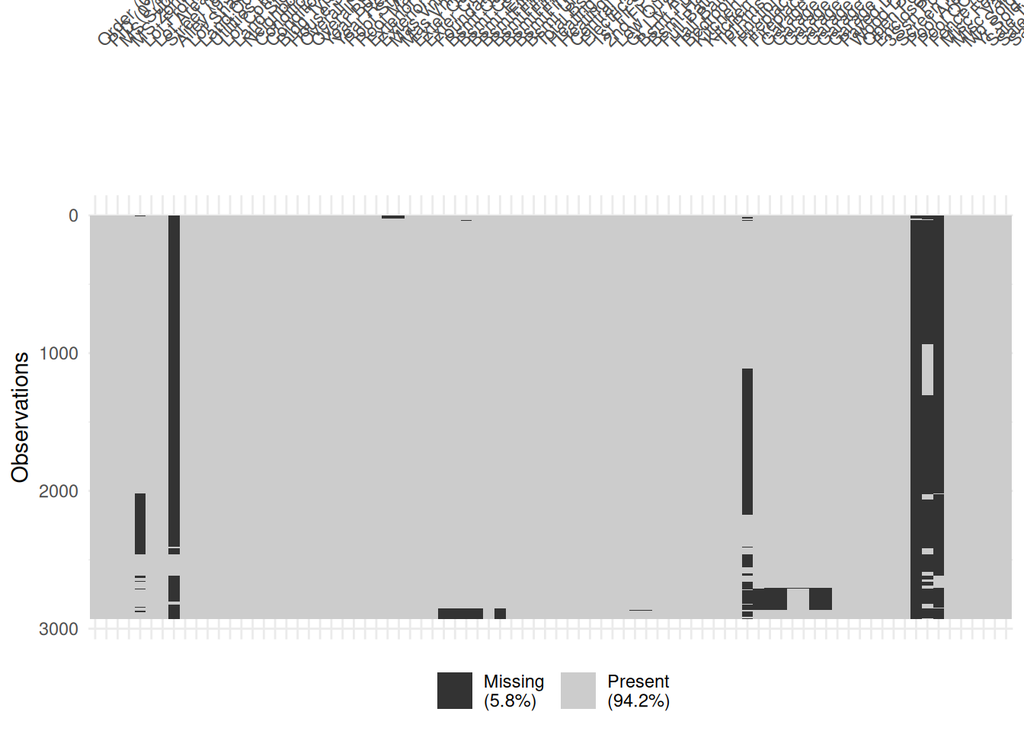

```r
library(visdat)

vis_miss(AmesHousing::ames_raw, cluster = TRUE)
```

Missing value imputation Features where null / missing values are less than 40% for categorical variables are replaced with mode which is value whose frequency is maximum.

```r
Mode = function(x){
  ta = table(x)
  tam = max(ta)
  mod = names(ta)[ta==tam]
  return(mod)
}
```

```r
for (col_name in colnames(ames[sapply(ames, is.factor) == TRUE])) {

  if (sum(is.na(ames[[col_name]])) > 0) {
    ames[col_name][is.na(ames[col_name])] <- Mode(ames[[col_name]])
    stmt <- paste('Null values of', col_name, ' feature has been replaced by mode value ',
                  Mode(ames[[col_name]]))
    print(stmt, na.print = NULL)
  }
}
```

$$\begin{align}
log(SalePrice) = \beta_{o}+\beta_{1}X_{1}\\
SalePrice = e^{\beta_{o}+\beta_{1}X_{1}}\\
SalePrice = B e^{\beta_{1}X_{1}}\\
\end{align}$$

## 4 References

Heaton, Jeff. 2016. “An Empirical Analysis of Feature Engineering for Predictive Modeling.” In *SoutheastCon 2016*, 1–6. Norfolk, VA, USA: IEEE. https://doi.org/10.1109/SECON.2016.7506650.